# Global Interpretation Methods: In-class Exercise 09-1

## Goal

Apply what you have learned about global interpretation methods to real data.

## Data

### Wines

For a later example, we will use the wine dataset, which includes quality ratings (assessed by blind tasting, on a scale from 0 to 10) for roughly 6500 red and white wines with given physiochemical properties: The dataset is loaded as follows:

```python
import pandas as pd
import numpy as np

wine = pd.read_csv("./wine.csv")
wine = wine.dropna()
wine['type'] = wine['type'].apply(lambda x: 1 if x == "red" else 0)
print("Wine data preview:")
wine.head()
```

```
Wine data preview:
```

|  | type | fixed acidity | volatile acidity | citric acid | residual sugar | chlorides | free sulfur dioxide | total sulfur dioxide | density | pH | sulphates | alcohol | quality |
| --- | --- | --- | --- | --- | --- | --- | --- | --- | --- | --- | --- | --- | --- |
| 0 | 0 | 7.0 | 0.27 | 0.36 | 20.7 | 0.045 | 45.0 | 170.0 | 1.0010 | 3.00 | 0.45 | 8.8 | 6 |
| 1 | 0 | 6.3 | 0.30 | 0.34 | 1.6 | 0.049 | 14.0 | 132.0 | 0.9940 | 3.30 | 0.49 | 9.5 | 6 |
| 2 | 0 | 8.1 | 0.28 | 0.40 | 6.9 | 0.050 | 30.0 | 97.0 | 0.9951 | 3.26 | 0.44 | 10.1 | 6 |
| 3 | 0 | 7.2 | 0.23 | 0.32 | 8.5 | 0.058 | 47.0 | 186.0 | 0.9956 | 3.19 | 0.40 | 9.9 | 6 |
| 4 | 0 | 7.2 | 0.23 | 0.32 | 8.5 | 0.058 | 47.0 | 186.0 | 0.9956 | 3.19 | 0.40 | 9.9 | 6 |

### Custom data

First, we will consider a toy example to understand how PDP and ALE, two global interpretation methods, handle correlated features. Imagine a simple data generating process (DGP) with two features, $x_1$ and $x_2$, that are highly correlated.

Furthermore, we assume that the outcome $y$ is created via the following DGP: $y = x_1 + x_2^2 + \epsilon, \ \epsilon \sim \mathcal{N}(0, 0.05^2)$.

```python
# 2. Create a toy dataset with two highly correlated features
rng = np.random.default_rng(seed=1234)
n_samples = 3000

x1 = rng.uniform(0, 1, size=n_samples)
x2 = x1 + rng.normal(0, 0.08, size=n_samples)

corr_matrix = np.corrcoef(x1, x2)
corr = corr_matrix[0, 1]
print(f"Pearson correlation between x1 and x2: {corr:.6f}\n")

eps = rng.normal(0, 0.05, size=n_samples)
y = x1 + x2**2 + eps

df = pd.DataFrame({"x1": x1, "x2": x2, "y": y})
print("Toy dataset preview:")
print(df.head())

X = df[["x1", "x2"]]
y_target = df["y"]
```

```
Pearson correlation between x1 and x2: 0.964018

Toy dataset preview:
         x1        x2         y
0  0.976700  1.023775  2.097081
1  0.380196  0.109607  0.399461
2  0.923246  1.044257  1.950334
3  0.261692  0.176428  0.274882
4  0.319097  0.481035  0.541057
```

Obviously, we can infer the true feature effects directly from the DGP:

Both $x_1$ and $x_2$ have positive effects on the outcome. Whereas y increases linearly with $x_1$, $x_2$ has a quadratic effect. Leveraging this knowledge about the true DGP, we can test and compare to what extent PDP and ALE recover these effects for a given machine learning model.

## Exercises

### Exercise 1: Fit a Neural Network

Fit a neural network using a simple train-test split, reserving 1,500 observations for testing.  
Since we are working in Python, we will use the `MLPRegressor` from `scikit-learn` as our learner. Set up a neural network with hidden layer sizes of 10 neurons (or deeper if needed) and a maximum of 1000 iterations.

After training, visualize the prediction surface for the test data by plotting the model's predictions across a grid covering the `x1` and `x2` feature space.

### Task Details

You will:

1. Split the dataset into a **training set** and a **test set** using a simple train-test split, reserving exactly **1,500 samples** for testing.
2. Fit a **neural network regressor** using `MLPRegressor` with appropriate hyperparameters:
   - Set `hidden_layer_sizes=(10,)` or a more complex structure like `(10, 10, 10)`.
   - Set `max_iter=1000`.
3. Train the model on the training data (`X_train`, `y_train`).
4. Visualize the **prediction surface** for the model:
   - Create a grid over the `x1` and `x2` space.
   - Predict the model output over this grid.
   - Plot the predicted values as a **contour plot**.
   - Optionally, overlay the test data points.

**Hint 1:**

You can use `plt.contourf()` from `matplotlib` to create a filled contour plot of the prediction surface.

```
Neural Network training completed. Training score: 0.9918, Test score: 0.9925
```

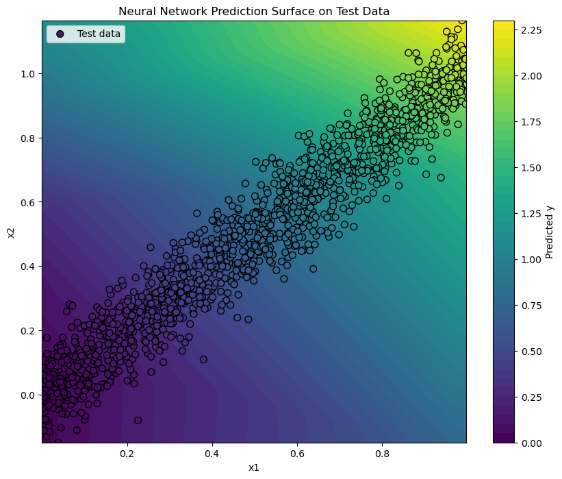

```python
#===SOLUTION===

from sklearn.model_selection import train_test_split
from sklearn.neural_network import MLPRegressor
import matplotlib.pyplot as plt


X_train, X_test, y_train, y_test = train_test_split(X, y_target, test_size=1500, random_state=1234)

mlp = MLPRegressor(
    hidden_layer_sizes=(10, 10, 10),
    max_iter=1000,
    random_state=1234,
    activation='relu',
    solver='adam',
    learning_rate_init=0.001,
    alpha=0.0001,
    early_stopping=True,
    validation_fraction=0.2,
    n_iter_no_change=50,
    tol=1e-6
)
mlp.fit(X_train, y_train)

print(f"Neural Network training completed. Training score: {mlp.score(X_train, y_train):.4f}, Test score: {mlp.score(X_test, y_test):.4f}")

# Visualize prediction surface for the model
# Create a grid covering the range of x1 and x2 in the test data
x1_min, x1_max = X_test['x1'].min(), X_test['x1'].max()
x2_min, x2_max = X_test['x2'].min(), X_test['x2'].max()

grid_points = 200

x1_grid = np.linspace(x1_min, x1_max, grid_points)
x2_grid = np.linspace(x2_min, x2_max, grid_points)
xx, yy = np.meshgrid(x1_grid, x2_grid)
grid = pd.DataFrame(np.c_[xx.ravel(), yy.ravel()], columns=['x1', 'x2'])

pred_grid = mlp.predict(grid).reshape(xx.shape)

plt.figure(figsize=(10, 8))
contour = plt.contourf(xx, yy, pred_grid, levels=50, cmap='viridis')
plt.colorbar(contour, label='Predicted y')

test_preds = mlp.predict(X_test)
plt.scatter(X_test['x1'], X_test['x2'], c=test_preds, edgecolor='k', cmap='viridis', marker='o', s=50, label='Test data')
plt.xlabel('x1')
plt.ylabel('x2')
plt.title('Neural Network Prediction Surface on Test Data')
plt.legend()
plt.show()
```

### Exercise 2: Compute PDP and ALE

To compute and visualize PDP and ALE, we will use **custom implementations** in this exercise.  
In **standard practice**, it is recommended to use `PartialDependenceDisplay` from `scikit-learn` for PDP plots, as it provides a tested and efficient implementation.  
However, for learning purposes, we will implement both **PDP** and **ALE** from scratch to better understand their mechanics.

In this task, you are asked to create **4 plots**:

- PDP for `x1`
- PDP for `x2`
- ALE plot for `x1`
- ALE plot for `x2`

Use the test data from the previous exercise to compute these plots.

### Task Details

You will:

1. Compute and plot **PDPs** for `x1` and `x2` based on your own implementation.
2. Compute and plot **ALEs** for `x1` and `x2`.
3. Use the test data (`X_test`) to compute both PDP and ALE.
4. Arrange the plots in a **2x2 grid**:
   - Row 1: PDP and ALE for `x1`.
   - Row 2: PDP and ALE for `x2`.

**Hint 1:**

For PDP, replace the feature values in the data with grid values and average the predictions.

**Hint 2:**

For ALE, compute local differences between predictions for small intervals, then accumulate and center the effects.

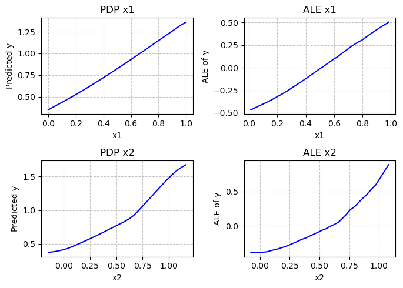

```python
#===SOLUTION===

fig, axs = plt.subplots(2, 2, figsize=(7, 5))


def compute_pdp(model, X, feature, grid_size=30):
    """Compute Partial Dependence Plot for a feature"""
    # Get feature name and values
    feature_name = X.columns[feature]
    feature_values = X[feature_name].values

    # Create grid for the feature
    grid_min, grid_max = feature_values.min(), feature_values.max()
    grid_points = np.linspace(grid_min, grid_max, grid_size)

    # Initialize array to store average predictions
    pdp_values = np.zeros(len(grid_points))

    # For each grid point
    for i, grid_val in enumerate(grid_points):
        # Create a copy of the dataset
        X_modified = X.copy()
        # Set the feature value to the grid point for all instances
        X_modified[feature_name] = grid_val
        # Predict with the modified dataset
        predictions = model.predict(X_modified)
        # Store the average prediction
        pdp_values[i] = np.mean(predictions)

    return grid_points, pdp_values

# PDP for x1 on test data (feature index 0)
x1_grid, x1_pdp = compute_pdp(mlp, X_test, feature=0, grid_size=30)
axs[0, 0].plot(x1_grid, x1_pdp, 'b-')
axs[0, 0].set_xlabel('x1')
axs[0, 0].set_ylabel('Predicted y')
axs[0, 0].set_title("PDP x1")
axs[0, 0].grid(True, linestyle='--', alpha=0.7)

# PDP for x2 on test data (feature index 1)
x2_grid, x2_pdp = compute_pdp(mlp, X_test, feature=1, grid_size=30)
axs[1, 0].plot(x2_grid, x2_pdp, 'b-')
axs[1, 0].set_xlabel('x2')
axs[1, 0].set_ylabel('Predicted y')
axs[1, 0].set_title("PDP x2")
axs[1, 0].grid(True, linestyle='--', alpha=0.7)


def compute_ale(model, X, feature, grid_size=30):
    """Compute Accumulated Local Effects for a feature"""
    # Get feature name and values
    feature_name = X.columns[feature]
    feature_values = X[feature_name].values

    # Create quantile-based grid for the feature
    quantiles = np.linspace(0, 1, grid_size + 1)
    grid_points = np.quantile(feature_values, quantiles)

    # Ensure grid points are unique
    grid_points = np.unique(grid_points)

    # Initialize arrays to store effects
    ale_values = np.zeros(len(grid_points) - 1)

    # For each interval in the grid
    for i in range(len(grid_points) - 1):
        # Find instances that fall within this interval
        mask = (feature_values >= grid_points[i]) & (feature_values <= grid_points[i + 1])
        instances = X[mask].copy()

        if len(instances) > 0:
            # Create two modified datasets with feature values at lower and upper bounds
            X_lower = instances.copy()
            X_upper = instances.copy()
            X_lower[feature_name] = grid_points[i]
            X_upper[feature_name] = grid_points[i + 1]

            # Predict with both modified datasets
            y_lower = model.predict(X_lower)
            y_upper = model.predict(X_upper)

            # Calculate local effect for each instance
            local_effects = y_upper - y_lower

            # Average local effects for this interval
            ale_values[i] = np.mean(local_effects)

    # Accumulate effects
    ale_accumulated = np.cumsum(ale_values)

    # Center ALE to have mean effect of 0
    ale_accumulated = ale_accumulated - np.mean(ale_accumulated)

    # Return grid midpoints and ALE values
    grid_midpoints = (grid_points[:-1] + grid_points[1:]) / 2
    return grid_midpoints, ale_accumulated

# ALE for x1 on test data (feature index 0)
x1_grid, x1_ale = compute_ale(mlp, X_test, feature=0, grid_size=30)
axs[0, 1].plot(x1_grid, x1_ale, 'b-')
axs[0, 1].set_xlabel('x1')
axs[0, 1].set_ylabel('ALE of y')
axs[0, 1].set_title("ALE x1")
axs[0, 1].grid(True, linestyle='--', alpha=0.7)

# ALE for x2 on test data (feature index 1)
x2_grid, x2_ale = compute_ale(mlp, X_test, feature=1, grid_size=30)
axs[1, 1].plot(x2_grid, x2_ale, 'b-')
axs[1, 1].set_xlabel('x2')
axs[1, 1].set_ylabel('ALE of y')
axs[1, 1].set_title("ALE x2")
axs[1, 1].grid(True, linestyle='--', alpha=0.7)

plt.tight_layout()
plt.show()
```

Question: Finally, interpret these plots. To what extent do PDP and ALE recover the true feature effects according to the DGP?

===SOLUTION===

ALE seems to reflect the ground truth: both the linear effect of $x_1$ and the quadratic effect of $x_2$ are recovered. The PDP, on the other hand, does not reflect the DGP. As discussed in the lecture, there is an extrapolation problem here.

Furthermore, compared to the result in the R solution where both effects of $x_1$ and $x_2$ are not well captured, our custom PDP implementation captures the linear effect of $x_1$, but it does not capture the quadratic effect of $x_2$.

## Exercise 3: Fit a Random Forest on the wine data

Let's fit a Random Forest model to predict the wine quality using the wine dataset. In Python, we will use the `RandomForestRegressor` from `scikit-learn` and perform a standard train-test split using `train_test_split()`. Then we fit the model on the training set.

```python
#===SOLUTION===

from sklearn.ensemble import RandomForestRegressor


X_wine = wine.drop(columns=["quality"])
y_wine = wine["quality"]

X_train_wine, X_test_wine, y_train_wine, y_test_wine = train_test_split(
    X_wine, y_wine, test_size=0.3, random_state=1234
)

rf = RandomForestRegressor(random_state=1234)
rf.fit(X_train_wine, y_train_wine)
```

```
RandomForestRegressor(random_state=1234)
```

## Exercise 4: PFI

**Feature permutation** is the process of randomly shuffling the observed values of a single feature in the dataset. This breaks the feature's relationship with the target and all other features, while preserving its marginal distribution.

The PFI measures the change in model performance before and after permuting a feature. Features whose permutation leads to a large decrease in performance are considered more important.

In `scikit-learn`, we can compute PFI using the `permutation_importance()` function.  
We will evaluate the **Random Forest** model you fitted in the previous exercise, using the MSE as the performance metric.

You will:

1. Compute **permutation feature importance** for the Random Forest model on the test data.
2. Use `permutation_importance()` with:
   - `scoring="neg_mean_squared_error"` to evaluate importance via MSE.
   - At least `n_repeats=10` to stabilize the estimates.
3. Plot the feature importances as a horizontal bar plot, sorted by importance.

**Hint 1:**

Check out `sklearn.inspection.permutation_importance()` to compute PFI directly on the trained model.

**Hint 2:**

The higher the decrease in performance (increase in MSE when permuted), the more important the feature.

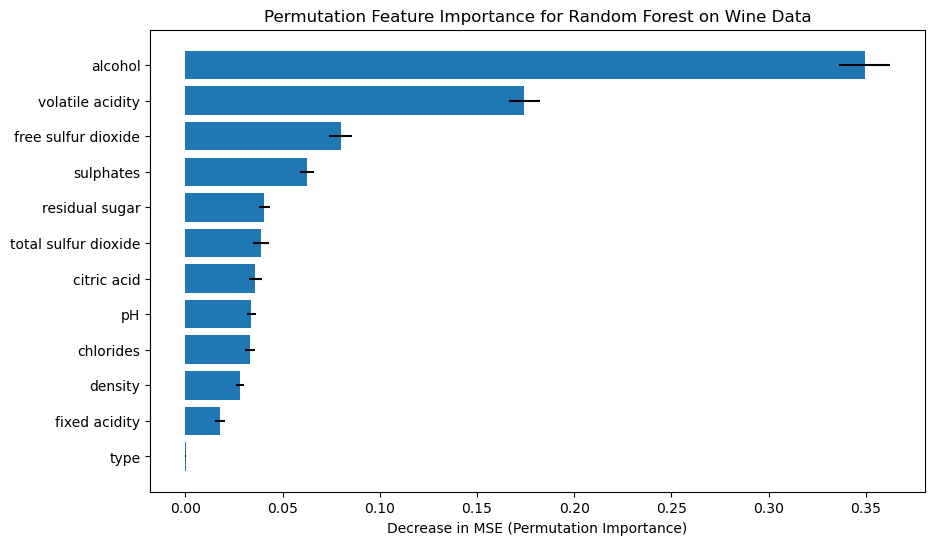

```python
#===SOLUTION===

from sklearn.inspection import permutation_importance

# We use the negative mean squared error as the scoring metric.
pfi_result = permutation_importance(
    rf, X_test_wine, y_test_wine,
    scoring='neg_mean_squared_error',
    n_repeats=10,
    random_state=1234
)

importances = pfi_result.importances_mean
std = pfi_result.importances_std

indices = np.argsort(importances)
sorted_features = X_test_wine.columns[indices]

# Plot the permutation feature importance as a horizontal bar plot
plt.figure(figsize=(10, 6))
plt.barh(range(len(importances)), importances[indices], xerr=std[indices], align='center')
plt.yticks(range(len(importances)), sorted_features)
plt.xlabel("Decrease in MSE (Permutation Importance)")
plt.title("Permutation Feature Importance for Random Forest on Wine Data")
plt.show()
```

## Exercise 5: LOCO

The LOCO method measures feature importance by removing each feature one at a time, retraining the model, and comparing its performance to the baseline model trained on all features. The performance drop indicates the feature's importance.

In this exercise, you will implement a function that:

1. Compute baseline performance using `cross_val_score()`.
2. For each feature:
   - Drop it from `X`.
   - Refit the model on the reduced dataset.
   - Compute the performance drop compared to the baseline.
3. Return the LOCO values for all features.

**Hint 1:**

Use `clone()` to reset the model for each reduced dataset and use `cross_val_score()` with `scoring="neg_mean_squared_error"` to evaluate model performance.

**Hint 2:**

The function should have the following signature and docstring:

```
def loco(X: pd.DataFrame,
         y: pd.Series,
         learner: BaseEstimator,
         cv: BaseCrossValidator,
         scoring: str) -> pd.Series:
    """
    Compute LOCO (Leave-One-Covariate-Out) values.

    Parameters:
      X: Feature data.
      y: Target variable.
      learner: The machine learning model to evaluate.
      cv: cross-validation splitter e.g., KFold, StratifiedKFold.
      scoring : Scoring metric; for MSE, use 'neg_mean_squared_error'.

    Returns:
      pd.Series
        A series with LOCO values for each feature.
    """
```

```python
#===SOLUTION===

from sklearn.model_selection import cross_val_score, KFold, BaseCrossValidator
from sklearn.base import clone, BaseEstimator


def loco(X: pd.DataFrame,
         y: pd.Series,
         learner: BaseEstimator,
         cv: BaseCrossValidator,
         scoring: str) -> pd.Series:
    """
    Compute LOCO (Leave-One-Covariate-Out) values.

    Parameters:
      X: Feature data.
      y: Target variable.
      learner: The machine learning model to evaluate.
      cv: cross-validation splitter e.g., KFold, StratifiedKFold.
      scoring : Scoring metric; for MSE, use 'neg_mean_squared_error'.

    Returns:
      pd.Series
        A series with LOCO values for each feature.
    """
    # Compute baseline performance on the full dataset:
    baseline_scores = cross_val_score(learner, X, y, cv=cv, scoring=scoring)
    # Aggregate baseline performance (mean across folds)
    baseline_perf = -np.mean(baseline_scores)

    loco_values = {}
    for feature in X.columns:
        # Create a reduced dataset by dropping one feature:
        X_reduced = X.drop(columns=[feature])

        # Clone the learner to ensure independence for each iteration:
        learner_reduced = clone(learner)

        # Compute performance on the reduced dataset:
        reduced_scores = cross_val_score(learner_reduced, X_reduced, y, cv=cv, scoring=scoring, n_jobs=-1)
        reduced_perf = -np.mean(reduced_scores)

        # LOCO: the increase in loss compared to the full model
        loco_values[feature] = reduced_perf - baseline_perf

    return pd.Series(loco_values)
```

## Exercise 6: LOCO vs. PFI - Calculation

In this exercise, you will compare LOCO and PFI on a toy dataset to observe how these methods behave when some features are informative and others are just noise or highly correlated.

The data-generating process is as follows: The outcome is given by $y = x_1 + \epsilon, \ \epsilon \sim \mathcal{N}(0, 0.1^2)$.  Additional noise features:

- $x_2$ and $x_3$ have no influence on $y$.
- $x_4$ is highly correlated with $x_3$ but also has no direct influence on $y$.

```python
# Generate the toy data
rng = np.random.default_rng(seed=1234)
n = 3000

x1 = rng.normal(0, 1, size=n)
y = x1 + rng.normal(0, 0.1, size=n)

# Other features: x2 and x3 are noise; x4 is highly correlated with x3
x2 = rng.normal(0, 1, size=n)
x3 = rng.normal(0, 1, size=n)
x4 = x3 + rng.normal(0, 0.01, size=n)

data = pd.DataFrame({"x1": x1, "x2": x2, "x3": x3, "x4": x4, "y": y})
X = data[["x1", "x2", "x3", "x4"]]
y_target = data["y"]
X_train, X_test, y_train, y_test = train_test_split(X, y_target, test_size=0.3, random_state=1234)
```

We fit a linear model on some training data.

```python
from sklearn.linear_model import LinearRegression

lrn_lm = LinearRegression()
lrn_lm.fit(X_train, y_train)
print("Linear Model Coefficients:")
coef_df = pd.DataFrame({
    "feature": X.columns,
    "coefficient": lrn_lm.coef_
})
print(coef_df, "\n")
```

```
Linear Model Coefficients:
  feature  coefficient
0      x1     1.004435
1      x2    -0.000325
2      x3     0.145220
3      x4    -0.144794
```

Now, you will:

1. Compute LOCO feature importances using the custom `loco()` function with Mean Absolute Error (MAE) as the performance metric.
2. Compute PFI using `permutation_importance()` with the same MAE metric.
3. Compare the feature importance derived from two methods.

**Hint 1:**

Use `scoring="neg_mean_absolute_error"` consistently in both LOCO and PFI to ensure comparability.

```python
#===SOLUTION===

cv = KFold(n_splits=5, shuffle=True, random_state=1234)
loco_values = loco(X, y_target, lrn_lm, cv, scoring='neg_mean_absolute_error')
print("LOCO values (increase in MAE):")
print(loco_values, "\n")
loco_df = pd.DataFrame({
    "feature": loco_values.index,
    "importance": loco_values.values
})

pfi = permutation_importance(
    lrn_lm, X_test, y_test,
    scoring='neg_mean_absolute_error',
    n_repeats=10,
    random_state=1234
)
pfi_importances = pfi.importances_mean
pfi_df = pd.DataFrame({
    "feature": X_test.columns,
    "importance": pfi_importances
})
print("PFI values (increase in MAE):")
print(pfi_df, "\n")
```

```
LOCO values (increase in MAE):
x1    0.740743
x2   -0.000008
x3   -0.000017
x4   -0.000017
dtype: float64

PFI values (increase in MAE):
  feature  importance
0      x1    1.078605
1      x2    0.000012
2      x3    0.102650
3      x4    0.106108
```

## Exercise 7: LOCO vs. PFI - Visualization

Visualize the LOCO values and PFI values.

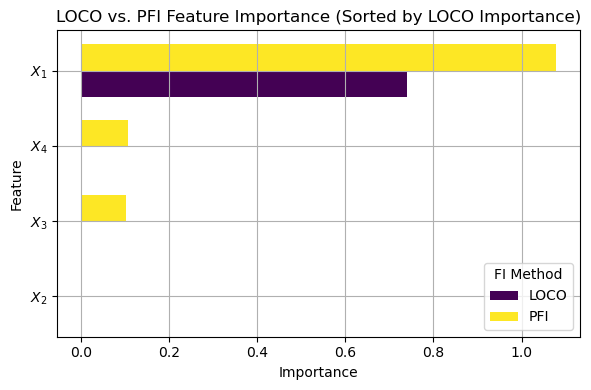

```python
#===SOLUTION===

feature_labels = {'x1': r'$X_1$', 'x2': r'$X_2$', 'x3': r'$X_3$', 'x4': r'$X_4$'}

# Sort features by LOCO importance
feature_order = pfi_df.sort_values('importance')['feature'].tolist()

plt.figure(figsize=(6, 4))

width = 0.35
y_pos = np.arange(len(feature_order))

ax = plt.gca()
ax.barh(y_pos - width/2,
       [loco_df[loco_df['feature'] == feat]['importance'].values[0] for feat in feature_order],
       width,
       label='LOCO',
       color='#440154')  # dark purple from viridis
ax.barh(y_pos + width/2,
       [pfi_df[pfi_df['feature'] == feat]['importance'].values[0] for feat in feature_order],
       width,
       label='PFI',
       color='#fde725')  # yellow from viridis

ax.set_xlabel('Importance')
ax.set_ylabel('Feature')
ax.set_title('LOCO vs. PFI Feature Importance (Sorted by LOCO Importance)')
ax.legend(title='FI Method')

ax.set_yticks(y_pos)
ax.set_yticklabels([feature_labels[feat] for feat in feature_order])

plt.tight_layout()
plt.grid(True)
plt.show()
```

Question: Interpret the results. Discuss your observation.

===SOLUTION===

Note that the feature importance values differ between methods. Here, LOCO correctly identifies $x_1$ as the only relevant feature in the DGP while PFI assigns non-zero values to $x_3$ and $x_4$ since these are highly correlated.

Print out the incercept and coefficients of the linear model. Then, re-analyze your observation in the plot above using these coefficients.

```python
#===SOLUTION===

print(f"Intercept: {lrn_lm.intercept_:.4f}")
print("\n".join([f"x_{i+1}: {coef:.5f}" for i, coef in enumerate(lrn_lm.coef_)]))
```

```
Intercept: 0.0002
x_1: 1.00444
x_2: -0.00032
x_3: 0.14522
x_4: -0.14479
```

===SOLUTION===

We see that the two coefficients of $x_3$ and $x_4$ cancel each other out as long as the dependence structure between these two features is preserved. As described above, permuting one of the two features destroys their correlation and thus also the described effect.

## Summary

We learned how to use the global interpretation methods PDP, ALE, PFI and LOCO.